# Appendix E — Statistical Inference Review

**STAT 418 · Computational Data Science** · runnable companion to the Statistical Inference Review appendix.

The main chapters *assume* the classical inferential toolkit. This appendix makes that toolkit **runnable**: instead of taking the sampling distribution, the coverage guarantee, or the power function on faith, we *simulate* them and watch the theory hold. Every simulation here uses `numpy.random.default_rng(42)`, which reproduces the exact numbers printed in the webbook — so you can check the prose against the code line by line.

## Learning outcomes

By the end you can:

1. Decompose an estimator's error into **bias** and **variance**, and show by simulation that a *biased* variance estimator can beat the unbiased $S^2$ in MSE.
2. Simulate the **sampling distribution** of $\bar X$ and $S^2$, confirm the exact Normal-theory results ($\bar X\sim N(\mu,\sigma^2/n)$, $(n-1)S^2/\sigma^2\sim\chi^2_{n-1}$, $\bar X\perp S^2$), and watch the **Central Limit Theorem** pull skewed parents toward $N(0,1)$.
3. Build **confidence intervals** from a pivot, verify the 95% **coverage guarantee** by Monte Carlo, and see it *break* for the Wald proportion interval at small $np$.
4. Run **hypothesis tests**: confirm p-values are Uniform under $H_0$, measure Type-I error, and trace the **power** function across effect size and sample size.

## Section map

| § | Topic | Core simulation |
| --- | --- | --- |
| E.1 | Point estimation: bias / variance / MSE | biased vs. unbiased $\hat\sigma^2$; Method of Moments |
| E.2 | Sampling distributions & the CLT | $\bar X$, $S^2$, $\chi^2$, the $t$ pivot; CLT convergence grid; **real data** (Morley) |
| E.3 | Confidence intervals & coverage | 100-interval caterpillar; Wald vs. Wilson breakdown |
| E.4 | Hypothesis testing: p-values & power | Uniform-under-$H_0$; power grid; multiple testing |
| E.5 | *Optional / self-study:* information, efficiency & asymptotics | Fisher info, CRLB, MLE normality, delta method |
| — | Exercises + Summary | coverage / power / p-value drills → Chapters 3–5 |

```python
import numpy as np
import pandas as pd
import matplotlib.pyplot as plt
from scipy import stats
%matplotlib inline

# STYLE.md asks for a fixed seed; this appendix's PUBLISHED numbers were produced with
# numpy's modern Generator seeded at 42, so every simulation cell below opens with
# rng = np.random.default_rng(42) to reproduce the webbook tables exactly.
np.random.seed(418)  # governs any incidental (figure-only) randomness

plt.rcParams.update({
    'figure.figsize': (7.2, 4.2), 'figure.dpi': 110,
    'axes.grid': True, 'grid.alpha': 0.25,
    'axes.spines.top': False, 'axes.spines.right': False,
    'font.size': 11,
})
BLUE, RED, GREEN, ORANGE, PURPLE = '#4C72B0', '#C44E52', '#55A868', '#DD8452', '#8172B3'

# One real dataset anchors the standard-error / CI / test discussion (E.2): the classic
# Michelson-Morley speed-of-light measurements, loaded straight from the course bucket.
MORLEY_URL = ('https://pqyjaywwccbnqpwgeiuv.supabase.co/storage/v1/object/public/'
              'STAT%20418%20Images/Data/Chapter5/morley.csv')

print('environment ready · numpy', np.__version__, '· scipy', stats.__name__)
```

```
environment ready · numpy 1.26.4 · scipy scipy.stats
```

## E.1 — Point Estimation: bias, variance, and MSE

An **estimator** $\hat\theta = T(X_1,\dots,X_n)$ is a function of the random sample, hence a random variable with its own **sampling distribution**. Its quality splits into two pieces that the **mean squared error** combines:

$$ \text{MSE}(\hat\theta) = \mathbb E\big[(\hat\theta-\theta)^2\big] = \underbrace{\big(\mathbb E[\hat\theta]-\theta\big)^2}_{\text{Bias}^2} + \underbrace{\text{Var}(\hat\theta)}_{\text{Variance}}. $$

Unbiasedness ($\text{Bias}=0$) is *desirable but not decisive*: a little bias can buy a large variance reduction. The textbook case is variance estimation. The **unbiased** $S^2$ uses Bessel's $1/(n-1)$; the **MLE** $\hat\sigma^2_{\text{MLE}}$ uses $1/n$ and carries bias $-\sigma^2/n$. Which has smaller MSE? We simulate $50{,}000$ samples from $N(5,2^2)$ at each $n$ and decompose the error.

```python
# Biased (MLE, 1/n) vs unbiased (S^2, 1/(n-1)) variance estimator -- MSE decomposition.
rng = np.random.default_rng(42)
mu, sigma = 5.0, 2.0
sigma2 = sigma**2
n_reps = 50000

ns, mse_b, mse_u, b2 = [], [], [], []
print(f"{'n':>5}  {'MSE(MLE 1/n)':>13}  {'MSE(S^2 1/(n-1))':>16}  {'Bias^2(MLE)':>12}  {'Winner':>8}")
print('-' * 64)
for n in [5, 10, 25, 50, 100]:
    biased = np.zeros(n_reps)
    unbiased = np.zeros(n_reps)
    for i in range(n_reps):
        s = rng.normal(mu, sigma, n)
        biased[i] = np.var(s, ddof=0)    # sigma^2_MLE
        unbiased[i] = np.var(s, ddof=1)  # S^2
    mb = np.mean((biased - sigma2)**2)
    mu_ = np.mean((unbiased - sigma2)**2)
    bias_sq = (np.mean(biased) - sigma2)**2
    winner = 'MLE' if mb < mu_ else 'S^2'
    ns.append(n); mse_b.append(mb); mse_u.append(mu_); b2.append(bias_sq)
    print(f"{n:>5}  {mb:>13.4f}  {mu_:>16.4f}  {bias_sq:>12.4f}  {winner:>8}")
print()
print('The BIASED MLE wins MSE at every n: its variance reduction outweighs its bias^2.')
print('Both MSEs -> 2*sigma^4/n = {:.4f} at n=100 as the bias term vanishes.'.format(2*sigma2**2/100))
```

```
    n   MSE(MLE 1/n)  MSE(S^2 1/(n-1))   Bias^2(MLE)    Winner
----------------------------------------------------------------
```

```
    5         5.8806            8.2137        0.6239       MLE
```

```
   10         3.0612            3.5863        0.1563       MLE
```

```
   25         1.2490            1.3263        0.0267       MLE
```

```
   50         0.6337            0.6524        0.0071       MLE
```

```
  100         0.3193            0.3241        0.0017       MLE

The BIASED MLE wins MSE at every n: its variance reduction outweighs its bias^2.
Both MSEs -> 2*sigma^4/n = 0.3200 at n=100 as the bias term vanishes.
```

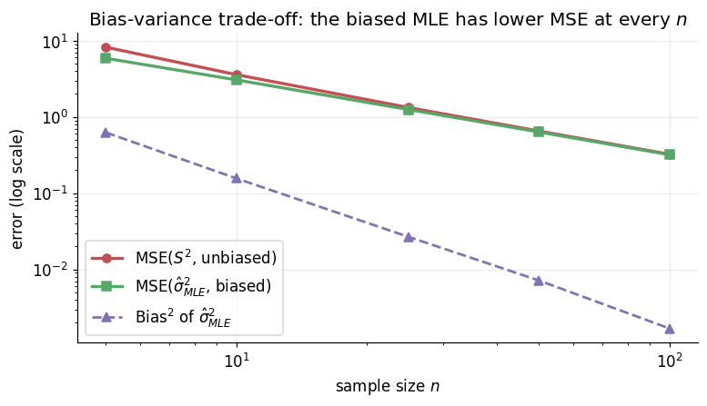

```python
# Figure: MSE(MLE) vs MSE(S^2) across n, with the bias^2 slice of the MLE's error.
fig, ax = plt.subplots()
ax.plot(ns, mse_u, 'o-', color=RED, lw=2.2, label=r'MSE($S^2$, unbiased)')
ax.plot(ns, mse_b, 's-', color=GREEN, lw=2.2, label=r'MSE($\hat\sigma^2_{MLE}$, biased)')
ax.plot(ns, b2, '^--', color=PURPLE, lw=1.8, label=r'Bias$^2$ of $\hat\sigma^2_{MLE}$')
ax.set_yscale('log'); ax.set_xscale('log')
ax.set_xlabel('sample size $n$'); ax.set_ylabel('error (log scale)')
ax.set_title('Bias-variance trade-off: the biased MLE has lower MSE at every $n$')
ax.legend(); plt.tight_layout(); plt.show()
```

**Read-out.** At $n=5$ the biased MLE's MSE is $5.88$ versus $8.21$ for $S^2$ — a 28% reduction bought with bias$^2 = 0.62$. The gap shrinks as $n$ grows (the bias is $-\sigma^2/n$), but the MLE wins at *every* sample size. Lesson: "unbiased" is not a synonym for "best."

### Method of Moments

The **method of moments** (MoM) equates sample moments to population moments and solves. For $\text{Gamma}(\alpha,\beta)$ (shape $\alpha$, scale $\beta$): $\mathbb E[X]=\alpha\beta$, $\mathbb E[X^2]=\alpha\beta^2(1+\alpha)$, giving the closed forms $\hat\beta = (m_2-m_1^2)/m_1$ and $\hat\alpha = m_1^2/(m_2-m_1^2)$. MoM needs no optimizer; the **MLE** (no closed form for the Gamma) is asymptotically efficient but must be solved numerically. We compare both on one $n=200$ sample from $\text{Gamma}(3,2)$.

```python
# Method of Moments vs MLE for Gamma(alpha=3, beta=2), n=200.
rng = np.random.default_rng(42)
alpha_true, beta_true, n = 3.0, 2.0, 200
sample = rng.gamma(alpha_true, beta_true, n)

m1 = np.mean(sample)
m2 = np.mean(sample**2)
beta_mom = m2 / m1 - m1
alpha_mom = m1 / beta_mom
alpha_mle, _, beta_mle = stats.gamma.fit(sample, floc=0)  # MLE, location fixed at 0

print(f'Gamma(alpha={alpha_true}, beta={beta_true}) sample, n={n}')
print(f'  sample moments : m1 = {m1:.4f}, m2 = {m2:.4f}')
print(f'  Method of Moments : alpha = {alpha_mom:.4f}, beta = {beta_mom:.4f}')
print(f'  Maximum Likelihood: alpha = {alpha_mle:.4f}, beta = {beta_mle:.4f}')
print(f'  True values       : alpha = {alpha_true:.4f}, beta = {beta_true:.4f}')
print('  Both land near the truth; MoM is closed-form, the MLE needs numerical optimization.')
```

```
Gamma(alpha=3.0, beta=2.0) sample, n=200
  sample moments : m1 = 6.2028, m2 = 50.5877
  Method of Moments : alpha = 3.1761, beta = 1.9529
  Maximum Likelihood: alpha = 3.2931, beta = 1.8836
  True values       : alpha = 3.0000, beta = 2.0000
  Both land near the truth; MoM is closed-form, the MLE needs numerical optimization.
```

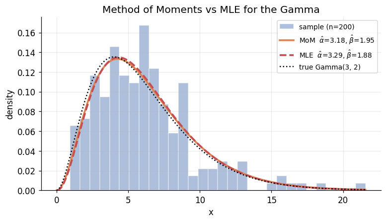

```python
# Figure: the Gamma sample with the MoM and MLE fitted densities.
fig, ax = plt.subplots()
xx = np.linspace(0, sample.max(), 400)
ax.hist(sample, bins=30, density=True, color=BLUE, alpha=0.45, edgecolor='white',
        label=f'sample (n={n})')
ax.plot(xx, stats.gamma.pdf(xx, alpha_mom, scale=beta_mom), color=ORANGE, lw=2.4,
        label=fr'MoM  $\hat\alpha$={alpha_mom:.2f}, $\hat\beta$={beta_mom:.2f}')
ax.plot(xx, stats.gamma.pdf(xx, alpha_mle, scale=beta_mle), '--', color=RED, lw=2.4,
        label=fr'MLE  $\hat\alpha$={alpha_mle:.2f}, $\hat\beta$={beta_mle:.2f}')
ax.plot(xx, stats.gamma.pdf(xx, alpha_true, scale=beta_true), ':', color='k', lw=1.6,
        label='true Gamma(3, 2)')
ax.set_xlabel('x'); ax.set_ylabel('density')
ax.set_title('Method of Moments vs MLE for the Gamma'); ax.legend(fontsize=9)
plt.tight_layout(); plt.show()
```

## E.2 — Sampling distributions and the Central Limit Theorem

The **sampling distribution** of a statistic is its distribution across hypothetical repeated samples. For $X_1,\dots,X_n\sim N(\mu,\sigma^2)$ the exact results are:

- $\displaystyle \bar X \sim N\!\big(\mu,\;\sigma^2/n\big)$,
- $\displaystyle (n-1)S^2/\sigma^2 \sim \chi^2_{n-1}$ (mean $n-1$, variance $2(n-1)$),
- $\bar X$ and $S^2$ are **independent** (special to the Normal),
- hence the pivot $T=(\bar X-\mu)/(S/\sqrt n)\sim t_{n-1}$.

We confirm all four by simulating $10{,}000$ samples at $n=15$ and $n=100$.

```python
# Sampling distributions of x-bar and S^2 for Normal(mu=5, sigma=2).
rng = np.random.default_rng(42)
mu, sigma = 5.0, 2.0
n_reps = 10000

for n in [15, 100]:
    xbar = np.zeros(n_reps); s2 = np.zeros(n_reps)
    for i in range(n_reps):
        s = rng.normal(mu, sigma, n)
        xbar[i] = np.mean(s); s2[i] = np.var(s, ddof=1)
    chi2_vals = (n - 1) * s2 / sigma**2
    corr = np.corrcoef(xbar, s2)[0, 1]
    print(f'n = {n} ({n_reps:,} replicates):')
    print(f'  x-bar : E = {np.mean(xbar):.4f} (theory {mu:.1f}),  Var = {np.var(xbar):.4f} (theory {sigma**2/n:.4f})')
    print(f'  S^2   : E = {np.mean(s2):.4f} (theory {sigma**2:.1f}),  SD = {np.std(s2):.4f}')
    print(f'  (n-1)S^2/sigma^2 : mean = {np.mean(chi2_vals):.4f} (theory {n-1}),  var = {np.var(chi2_vals):.4f} (theory {2*(n-1):.1f})')
    print(f'  Corr(x-bar, S^2) = {corr:.4f} (theory 0 -- independence)')
    print()
```

```
n = 15 (10,000 replicates):
  x-bar : E = 4.9933 (theory 5.0),  Var = 0.2674 (theory 0.2667)
  S^2   : E = 4.0346 (theory 4.0),  SD = 1.5425
  (n-1)S^2/sigma^2 : mean = 14.1211 (theory 14),  var = 29.1477 (theory 28.0)
  Corr(x-bar, S^2) = 0.0202 (theory 0 -- independence)

n = 100 (10,000 replicates):
  x-bar : E = 5.0021 (theory 5.0),  Var = 0.0391 (theory 0.0400)
  S^2   : E = 3.9965 (theory 4.0),  SD = 0.5682
  (n-1)S^2/sigma^2 : mean = 98.9146 (theory 99),  var = 197.7431 (theory 198.0)
  Corr(x-bar, S^2) = 0.0235 (theory 0 -- independence)
```

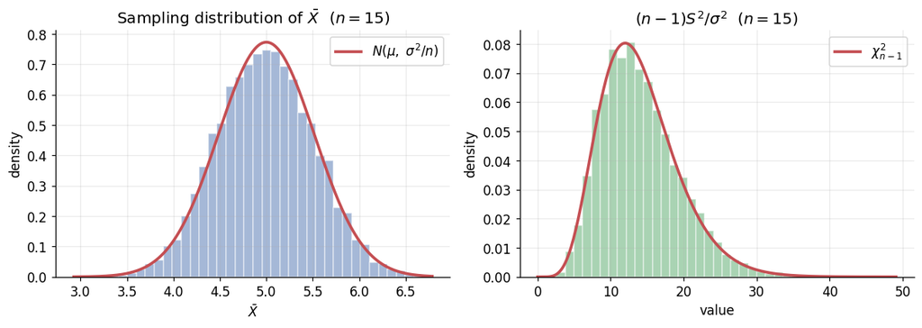

```python
# Figure: at n=15, x-bar matches N(mu, sigma^2/n) and (n-1)S^2/sigma^2 matches chi^2_{n-1}.
rng = np.random.default_rng(42)
n = 15; R = 8000
xbar = np.zeros(R); chi = np.zeros(R)
for i in range(R):
    s = rng.normal(mu, sigma, n)
    xbar[i] = np.mean(s)
    chi[i] = (n - 1) * np.var(s, ddof=1) / sigma**2

fig, axes = plt.subplots(1, 2, figsize=(11, 4))
ax = axes[0]
ax.hist(xbar, bins=40, density=True, color=BLUE, alpha=0.5, edgecolor='white')
gx = np.linspace(xbar.min(), xbar.max(), 300)
ax.plot(gx, stats.norm.pdf(gx, mu, sigma/np.sqrt(n)), color=RED, lw=2.4,
        label=r'$N(\mu,\ \sigma^2/n)$')
ax.set_title(r'Sampling distribution of $\bar X$  ($n=15$)')
ax.set_xlabel(r'$\bar X$'); ax.set_ylabel('density'); ax.legend()

ax = axes[1]
ax.hist(chi, bins=40, density=True, color=GREEN, alpha=0.5, edgecolor='white')
cx = np.linspace(0, chi.max(), 300)
ax.plot(cx, stats.chi2.pdf(cx, n - 1), color=RED, lw=2.4, label=r'$\chi^2_{n-1}$')
ax.set_title(r'$(n-1)S^2/\sigma^2$  ($n=15$)')
ax.set_xlabel('value'); ax.set_ylabel('density'); ax.legend()
plt.tight_layout(); plt.show()
```

### The $t$ pivot: the price of estimating $\sigma$

```python
# Z (known sigma) vs T (estimated sigma) pivots for Normal(5, 2^2), n=15.
rng = np.random.default_rng(42)
mu, sigma, n = 5.0, 2.0, 15
n_reps = 10000
z_vals = np.zeros(n_reps); t_vals = np.zeros(n_reps); se_vals = np.zeros(n_reps)
for i in range(n_reps):
    s = rng.normal(mu, sigma, n)
    xb = np.mean(s); sd = np.std(s, ddof=1)
    z_vals[i] = (xb - mu) / (sigma / np.sqrt(n))
    t_vals[i] = (xb - mu) / (sd / np.sqrt(n))
    se_vals[i] = sd / np.sqrt(n)

print('Pivots for Normal(mu=5, sigma=2), n=15:')
print(f"{'':>18}  {'Z (known s)':>12}  {'T (est. s)':>12}")
print('-' * 46)
print(f"{'Variance':>18}  {np.var(z_vals):>12.4f}  {np.var(t_vals):>12.4f}")
print(f"{'  theory':>18}  {1.0:>12.4f}  {(n-1)/(n-3):>12.4f}")
print(f"{'Excess kurtosis':>18}  {stats.kurtosis(z_vals):>12.4f}  {stats.kurtosis(t_vals):>12.4f}")
print(f"{'  theory':>18}  {0.0:>12.4f}  {6/(n-5):>12.4f}")
print(f"{'2.5th pct':>18}  {np.percentile(z_vals,2.5):>12.4f}  {np.percentile(t_vals,2.5):>12.4f}")
print(f"{'  theory':>18}  {stats.norm.ppf(0.025):>12.4f}  {stats.t.ppf(0.025, n-1):>12.4f}")
print()
print(f'Estimated SE: E[S/sqrt(n)] = {np.mean(se_vals):.4f}  (theory sigma/sqrt(n) = {sigma/np.sqrt(n):.4f})')
```

```
Pivots for Normal(mu=5, sigma=2), n=15:
                     Z (known s)    T (est. s)
----------------------------------------------
          Variance        1.0028        1.1608
            theory        1.0000        1.1667
   Excess kurtosis       -0.1494        0.3359
            theory        0.0000        0.6000
         2.5th pct       -1.9363       -2.1474
            theory       -1.9600       -2.1448

Estimated SE: E[S/sqrt(n)] = 0.5093  (theory sigma/sqrt(n) = 0.5164)
```

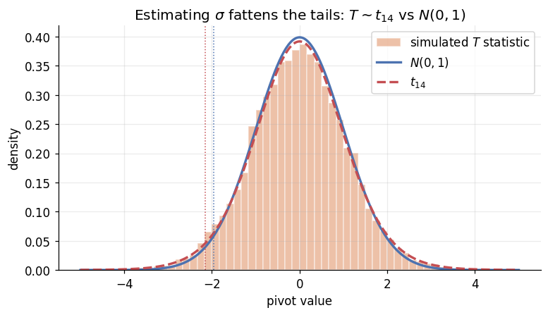

```python
# Figure: T has visibly heavier tails than the standard Normal.
fig, ax = plt.subplots()
xx = np.linspace(-5, 5, 400)
ax.hist(t_vals, bins=60, range=(-5, 5), density=True, color=ORANGE, alpha=0.5,
        edgecolor='white', label=r'simulated $T$ statistic')
ax.plot(xx, stats.norm.pdf(xx), color=BLUE, lw=2.2, label=r'$N(0,1)$')
ax.plot(xx, stats.t.pdf(xx, n - 1), '--', color=RED, lw=2.2, label=r'$t_{14}$')
ax.axvline(stats.norm.ppf(0.025), color=BLUE, lw=1, ls=':')
ax.axvline(stats.t.ppf(0.025, n - 1), color=RED, lw=1, ls=':')
ax.set_xlabel('pivot value'); ax.set_ylabel('density')
ax.set_title(r'Estimating $\sigma$ fattens the tails: $T\sim t_{14}$ vs $N(0,1)$')
ax.legend(); plt.tight_layout(); plt.show()
```

### The Central Limit Theorem in action

For **non-Normal** parents the exact results fail, but the CLT rescues the mean: the standardized average $Z_n=\sqrt n(\bar X-\mu)/\sigma \xrightarrow{d} N(0,1)$ *regardless of the parent's shape*. Convergence speed is governed by the parent's **skewness** (Berry-Esseen: error $=O(1/\sqrt n)$). We track the first four moments of $Z_n$ for three parents of decreasing skewness: $\text{Exp}(1)$ ($\gamma_1=2$), $\chi^2_3$ ($\gamma_1\approx1.63$), $\text{Bernoulli}(0.3)$ ($\gamma_1\approx0.87$).

```python
# CLT: moments of the standardized mean Z_n should approach N(0,1): mean 0, var 1, skew 0, kurt 0.
rng = np.random.default_rng(42)
n_reps = 10000
specs = [
    ('Exp(1)',      lambda k: rng.exponential(1.0, k),   1.0, 1.0),
    ('Chi^2(3)',    lambda k: rng.chisquare(3, k),       3.0, np.sqrt(6)),
    ('Bern(0.3)',   lambda k: rng.binomial(1, 0.3, k),   0.3, np.sqrt(0.3*0.7)),
]
print('Standardized mean Z_n -> N(0,1)   (targets: Mean 0, Var 1, Skew 0, Kurt 0)')
print(f"{'parent':>12}  {'n':>5}  {'Mean':>7}  {'Var':>7}  {'Skew':>7}  {'Kurt':>7}")
print('-' * 52)
for name, sampler, m, sd in specs:
    for n in [5, 15, 50, 200]:
        z = np.zeros(n_reps)
        for i in range(n_reps):
            z[i] = (np.mean(sampler(n)) - m) / (sd / np.sqrt(n))
        print(f"{name:>12}  {n:>5}  {np.mean(z):>7.3f}  {np.var(z):>7.3f}  "
              f"{stats.skew(z):>7.3f}  {stats.kurtosis(z):>7.3f}")
    print()
print('Mean & variance lock in immediately; skewness is the slow coordinate and shrinks ~1/sqrt(n).')
```

```
Standardized mean Z_n -> N(0,1)   (targets: Mean 0, Var 1, Skew 0, Kurt 0)
      parent      n     Mean      Var     Skew     Kurt
----------------------------------------------------
      Exp(1)      5    0.001    1.021    0.934    1.284
      Exp(1)     15   -0.005    1.007    0.502    0.315
      Exp(1)     50   -0.009    0.977    0.282    0.154
```

```
      Exp(1)    200   -0.002    1.004    0.175    0.055

    Chi^2(3)      5   -0.003    1.012    0.760    0.823
    Chi^2(3)     15    0.023    1.005    0.405    0.253
    Chi^2(3)     50    0.011    1.007    0.232    0.096
```

```
    Chi^2(3)    200   -0.002    1.003    0.120    0.135

   Bern(0.3)      5   -0.001    1.002    0.404   -0.197
   Bern(0.3)     15    0.002    0.978    0.270    0.012
   Bern(0.3)     50   -0.003    0.993    0.069   -0.085
```

```
   Bern(0.3)    200   -0.003    0.987    0.064   -0.046

Mean & variance lock in immediately; skewness is the slow coordinate and shrinks ~1/sqrt(n).
```

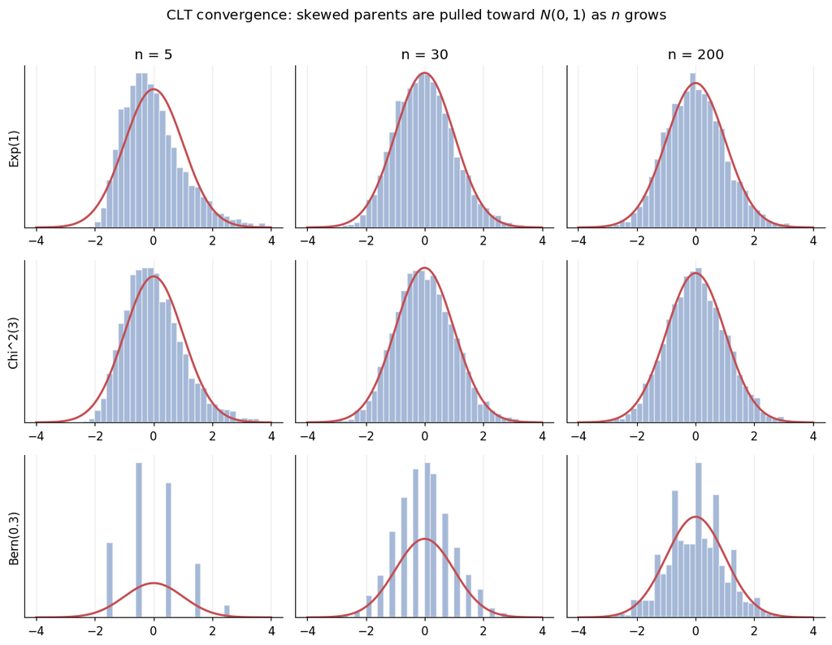

```python
# Figure: histograms of Z_n for the three parents as n grows (red curve = N(0,1)).
rng = np.random.default_rng(42)
fig, axes = plt.subplots(3, 3, figsize=(11, 8.4))
cols = [5, 30, 200]
xx = np.linspace(-4, 4, 300)
for r, (name, sampler, m, sd) in enumerate(specs):
    for c, n in enumerate(cols):
        z = np.zeros(5000)
        for i in range(5000):
            z[i] = (np.mean(sampler(n)) - m) / (sd / np.sqrt(n))
        ax = axes[r, c]
        ax.hist(z, bins=40, range=(-4, 4), density=True, color=BLUE, alpha=0.5, edgecolor='white')
        ax.plot(xx, stats.norm.pdf(xx), color=RED, lw=2)
        ax.set_yticks([])
        if r == 0:
            ax.set_title(f'n = {n}')
        if c == 0:
            ax.set_ylabel(name, fontsize=11)
fig.suptitle('CLT convergence: skewed parents are pulled toward $N(0,1)$ as $n$ grows', y=1.0)
plt.tight_layout(); plt.show()
```

### Real-data anchor: Michelson-Morley speed of light

The standard error and the $t$-interval are not just simulation artifacts — here they are on **real measurements**. Michelson's 1879 experiment recorded $n=100$ speed-of-light values (reported as km/s $-\,299000$). We compute $\bar X$, $S$, the estimated $\text{SE}=S/\sqrt n$, the 95% $t$-interval, and — previewing E.4's **duality** — test $H_0$: the mean equals the modern accepted value $792.458$ (i.e. $299{,}792.458$ km/s).

```python
# Real data: Michelson-Morley speed-of-light measurements (km/s - 299000).
morley = pd.read_csv(MORLEY_URL)
x = morley['Speed'].astype(float).to_numpy()
n = len(x)
xbar = x.mean()
s = x.std(ddof=1)
se = s / np.sqrt(n)
t_crit = stats.t.ppf(0.975, n - 1)
ci = (xbar - t_crit * se, xbar + t_crit * se)

print(f'Michelson 1879: n = {n} measurements of (speed of light - 299000) km/s')
print(f'  x-bar = {xbar:.2f}   S = {s:.3f}   SE = S/sqrt(n) = {se:.3f}')
print(f'  95% t-interval: [{ci[0]:.2f}, {ci[1]:.2f}]   (t_crit = {t_crit:.4f}, df = {n-1})')
print(f'  => Michelson estimated c ~ {299000 + xbar:.1f} km/s')

# Duality preview: one-sample t-test against the modern accepted value.
mu0 = 792.458   # 299792.458 - 299000
t_stat = (xbar - mu0) / se
p_val = 2 * stats.t.sf(abs(t_stat), n - 1)
print()
print(f'  H0: mu = {mu0} (modern value).  t = {t_stat:.3f}, two-sided p = {p_val:.2e}')
print(f'  {mu0} lies OUTSIDE the 95% interval -> reject H0: a real ~{xbar-mu0:.0f} km/s upward bias.')
print('  (CI and test agree by construction -- the duality formalized in E.4.)')
```

```
Michelson 1879: n = 100 measurements of (speed of light - 299000) km/s
  x-bar = 852.40   S = 79.011   SE = S/sqrt(n) = 7.901
  95% t-interval: [836.72, 868.08]   (t_crit = 1.9842, df = 99)
  => Michelson estimated c ~ 299852.4 km/s

  H0: mu = 792.458 (modern value).  t = 7.587, two-sided p = 1.82e-11
  792.458 lies OUTSIDE the 95% interval -> reject H0: a real ~60 km/s upward bias.
  (CI and test agree by construction -- the duality formalized in E.4.)
```

## E.3 — Confidence intervals and the coverage guarantee

A $1-\alpha$ confidence interval is a *random* interval $[L,U]$ with $P_\theta(L\le\theta\le U)\ge 1-\alpha$ **for all** $\theta$. The probability is over the endpoints, not over the fixed $\theta$: *"95% confidence"* means the **procedure** captures $\theta$ in 95% of repetitions — not that any one realized interval has a 95% chance of containing it. We make that operational by building 100 independent 95% $t$-intervals for a known $\mu=5$ and counting captures.

```python
# Coverage of the 95% t-interval: simulate many intervals for a KNOWN mu and count hits.
rng = np.random.default_rng(42)
mu, sigma, n = 5.0, 2.0, 25
alpha = 0.05
t_crit = stats.t.ppf(1 - alpha/2, df=n - 1)

# 200 intervals for the headline coverage number...
captures = 0
for i in range(200):
    s = rng.normal(mu, sigma, n)
    se = np.std(s, ddof=1) / np.sqrt(n)
    lo, hi = np.mean(s) - t_crit*se, np.mean(s) + t_crit*se
    captures += (lo <= mu <= hi)
print(f'95% t-intervals (n={n}, 200 intervals): captured mu in {captures}/200 = {captures/200:.1%}')
print(f'  expected ~190 captures; t critical value = {t_crit:.4f}')

# ...and store the first 100 (with capture flags) for the caterpillar plot.
rng = np.random.default_rng(7)
los, his, mids, hit = [], [], [], []
for i in range(100):
    s = rng.normal(mu, sigma, n)
    se = np.std(s, ddof=1) / np.sqrt(n)
    m = np.mean(s)
    lo, hi = m - t_crit*se, m + t_crit*se
    los.append(lo); his.append(hi); mids.append(m); hit.append(lo <= mu <= hi)
print(f'  caterpillar sample: {sum(hit)}/100 intervals cover mu = {mu}')
```

```
95% t-intervals (n=25, 200 intervals): captured mu in 187/200 = 93.5%
  expected ~190 captures; t critical value = 2.0639
  caterpillar sample: 94/100 intervals cover mu = 5.0
```

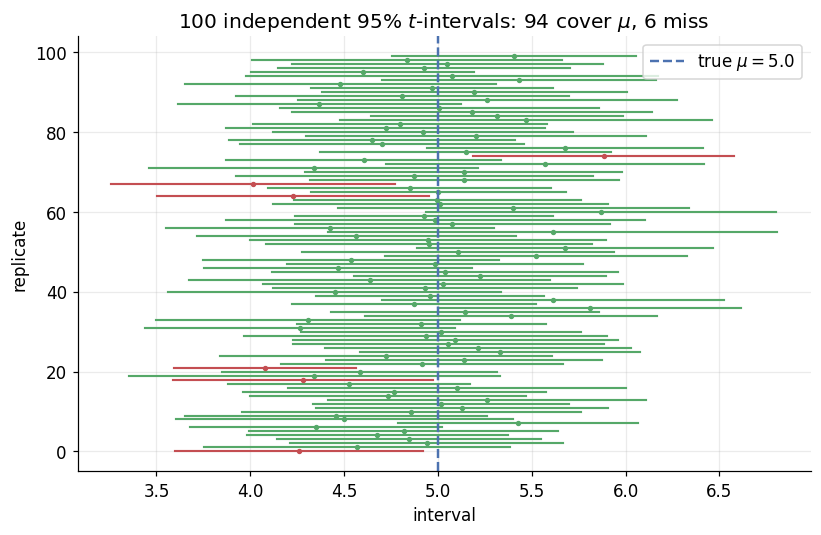

```python
# Figure: 100 confidence intervals; green = covers mu, red = misses.
fig, ax = plt.subplots(figsize=(7.6, 5.0))
for i in range(100):
    c = GREEN if hit[i] else RED
    ax.plot([los[i], his[i]], [i, i], color=c, lw=1.4)
    ax.plot(mids[i], i, 'o', color=c, ms=2.5)
ax.axvline(mu, color=BLUE, lw=1.6, ls='--', label=fr'true $\mu={mu}$')
ax.set_xlabel('interval'); ax.set_ylabel('replicate')
ax.set_title(f'100 independent 95% $t$-intervals: {sum(hit)} cover $\\mu$, {100-sum(hit)} miss')
ax.legend(loc='upper right'); plt.tight_layout(); plt.show()
```

### When coverage breaks: the Wald proportion interval

The coverage guarantee is only as good as the pivot's distributional assumption. The **Wald** interval for a proportion, $\hat p \pm z\sqrt{\hat p(1-\hat p)/n}$, is the textbook default but *under-covers badly* when $np$ is small — and collapses to $[0,0]$ whenever $\hat p=0$. The **Wilson** (score) interval fixes it. We measure actual coverage of nominal-95% intervals for $p=0.05$ across $n$, with $50{,}000$ replicates each.

```python
# Wald vs Wilson coverage for a small proportion p = 0.05.
rng = np.random.default_rng(42)
p_true = 0.05
n_reps = 50000
z = 1.96
ns_p, cov_wald, cov_wilson = [], [], []
print('Coverage of nominal-95% CI for Binomial proportion (p = 0.05)')
print(f"{'n':>5}  {'n*p':>5}  {'Wald':>8}  {'Wilson':>8}")
print('-' * 33)
for n in [10, 20, 50, 200]:
    wald = wilson = 0
    for i in range(n_reps):
        x = rng.binomial(n, p_true); ph = x / n
        se = np.sqrt(ph*(1-ph)/n)
        if ph - z*se <= p_true <= ph + z*se:
            wald += 1
        den = 1 + z**2/n
        center = (ph + z**2/(2*n)) / den
        margin = z*np.sqrt(ph*(1-ph)/n + z**2/(4*n**2)) / den
        if center - margin <= p_true <= center + margin:
            wilson += 1
    ns_p.append(n); cov_wald.append(wald/n_reps); cov_wilson.append(wilson/n_reps)
    print(f"{n:>5}  {n*p_true:>5.1f}  {wald/n_reps:>8.3f}  {wilson/n_reps:>8.3f}")
print()
print('Wald is catastrophic at n=10 (40.3% vs nominal 95%) and still under-covers at n=200.')
print('Wilson holds above 90% throughout -- it inverts the better-behaved score test.')
```

```
Coverage of nominal-95% CI for Binomial proportion (p = 0.05)
    n    n*p      Wald    Wilson
---------------------------------
   10    0.5     0.403     0.914
```

```
   20    1.0     0.640     0.924
   50    2.5     0.922     0.963
```

```
  200   10.0     0.925     0.966

Wald is catastrophic at n=10 (40.3% vs nominal 95%) and still under-covers at n=200.
Wilson holds above 90% throughout -- it inverts the better-behaved score test.
```

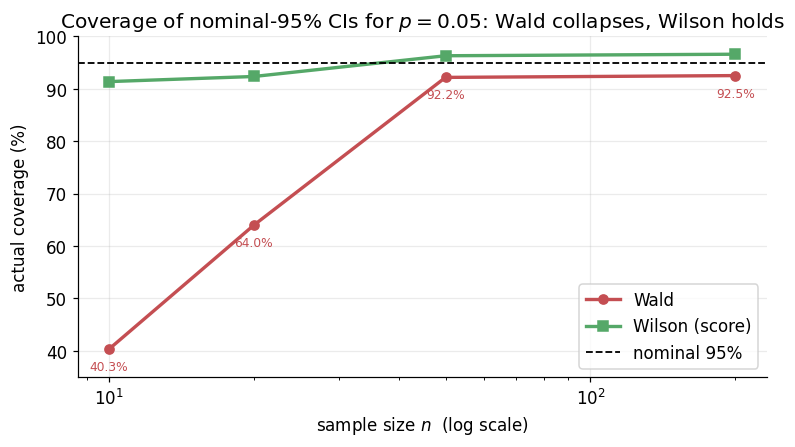

```python
# Figure: actual coverage vs n for the two proportion intervals.
fig, ax = plt.subplots()
ax.plot(ns_p, [100*c for c in cov_wald], 'o-', color=RED, lw=2.2, label='Wald')
ax.plot(ns_p, [100*c for c in cov_wilson], 's-', color=GREEN, lw=2.2, label='Wilson (score)')
ax.axhline(95, color='k', ls='--', lw=1.2, label='nominal 95%')
ax.set_xscale('log')
for n, c in zip(ns_p, cov_wald):
    ax.annotate(f'{100*c:.1f}%', (n, 100*c), textcoords='offset points', xytext=(0, -14),
                ha='center', fontsize=8, color=RED)
ax.set_xlabel('sample size $n$  (log scale)'); ax.set_ylabel('actual coverage (%)')
ax.set_title('Coverage of nominal-95% CIs for $p=0.05$: Wald collapses, Wilson holds')
ax.set_ylim(35, 100); ax.legend(loc='lower right'); plt.tight_layout(); plt.show()
```

**Read-out.** The Normal-theory $t$-interval delivers its promised coverage ($93.5\%$ over 200 intervals — within sampling noise of 95%). The Wald proportion interval does **not**: at $n=10,\ p=0.05$ it covers only $40.3\%$ of the time, because $\hat p=0$ occurs with probability $0.95^{10}\approx0.60$ and then the interval is the useless $[0,0]$. **Confidence-interval / hypothesis-test duality:** a $1-\alpha$ CI is exactly the set of $\theta_0$ a level-$\alpha$ two-sided test would *not* reject — which is why the Morley value $792.458$ falling outside the interval and the test rejecting $H_0$ are the same statement.

## E.4 — Hypothesis testing: p-values and power

A test fixes a default $H_0$, a statistic $T$, and a rejection region, controlling the **Type-I error** $\alpha=P(\text{reject}\mid H_0)$ by design. The **p-value** $p=P_{H_0}(|T|\ge|t_{\text{obs}}|)$ measures surprise under $H_0$. A key calibration fact:

> **If $H_0$ is true and $T$ is continuous, the p-value is $\text{Uniform}(0,1)$.**

So under $H_0$ each decile of $[0,1]$ should hold $\approx10\%$ of p-values, and $P(p<\alpha)=\alpha$ exactly. Under $H_1$ the p-value distribution shifts toward 0; the mass below $\alpha$ is the **power**. We simulate the one-sample two-sided $t$-test, $n=25$, under $H_0:\mu=0$ and $H_1:\mu=0.5$ (effect size $\delta/\sigma=0.5$).

```python
# P-values under H0 (mu=0) and H1 (mu=0.5): two-sided one-sample t-test, n=25.
rng = np.random.default_rng(42)
n = 25; n_reps = 10000

pvals_h0 = np.zeros(n_reps)
for i in range(n_reps):
    s = rng.normal(0.0, 1.0, n)
    t = np.mean(s) / (np.std(s, ddof=1) / np.sqrt(n))
    pvals_h0[i] = 2 * stats.t.sf(abs(t), df=n - 1)

pvals_h1 = np.zeros(n_reps)
for i in range(n_reps):
    s = rng.normal(0.5, 1.0, n)
    t = np.mean(s) / (np.std(s, ddof=1) / np.sqrt(n))
    pvals_h1[i] = 2 * stats.t.sf(abs(t), df=n - 1)

print('Two-sided one-sample t-test, n=25')
print('Under H0 (mu=0):')
print(f'  mean p-value      = {np.mean(pvals_h0):.4f}  (theory 0.5000)')
print(f'  reject at a=0.05  = {np.mean(pvals_h0 < 0.05):.4f}  (theory 0.0500 = Type-I rate)')
print(f'  reject at a=0.01  = {np.mean(pvals_h0 < 0.01):.4f}  (theory 0.0100)')
print(f'  fraction in [0.4,0.6) = {np.mean((pvals_h0>=0.4)&(pvals_h0<0.6)):.4f}  (theory 0.2000 -- uniform)')
print('Under H1 (mu=0.5, delta/sigma=0.5):')
print(f'  mean p-value      = {np.mean(pvals_h1):.4f}')
print(f'  power at a=0.05   = {np.mean(pvals_h1 < 0.05):.4f}')
print(f'  power at a=0.01   = {np.mean(pvals_h1 < 0.01):.4f}')
print('  => n=25 has only ~67% power vs a medium effect: it misses one in three real effects.')
```

```
Two-sided one-sample t-test, n=25
Under H0 (mu=0):
  mean p-value      = 0.5001  (theory 0.5000)
  reject at a=0.05  = 0.0518  (theory 0.0500 = Type-I rate)
  reject at a=0.01  = 0.0103  (theory 0.0100)
  fraction in [0.4,0.6) = 0.1985  (theory 0.2000 -- uniform)
Under H1 (mu=0.5, delta/sigma=0.5):
  mean p-value      = 0.0808
  power at a=0.05   = 0.6654
  power at a=0.01   = 0.3992
  => n=25 has only ~67% power vs a medium effect: it misses one in three real effects.
```

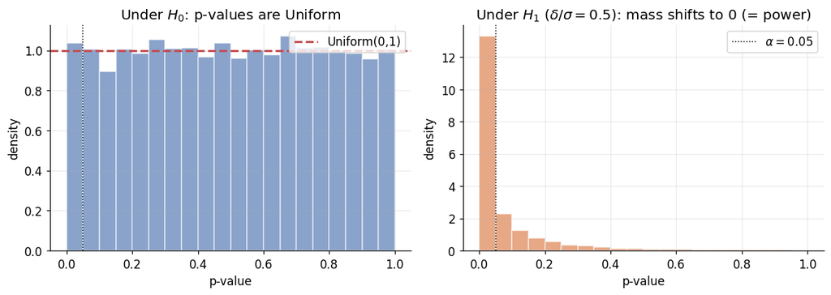

```python
# Figure: p-value histograms -- flat under H0, piled near 0 under H1.
fig, axes = plt.subplots(1, 2, figsize=(11, 4))
ax = axes[0]
ax.hist(pvals_h0, bins=20, range=(0, 1), density=True, color=BLUE, alpha=0.65, edgecolor='white')
ax.axhline(1.0, color=RED, lw=2, ls='--', label='Uniform(0,1)')
ax.axvline(0.05, color='k', lw=1, ls=':')
ax.set_title(r'Under $H_0$: p-values are Uniform'); ax.set_xlabel('p-value'); ax.set_ylabel('density')
ax.legend()
ax = axes[1]
ax.hist(pvals_h1, bins=20, range=(0, 1), density=True, color=ORANGE, alpha=0.7, edgecolor='white')
ax.axvline(0.05, color='k', lw=1, ls=':', label=r'$\alpha=0.05$')
ax.set_title(r'Under $H_1$ ($\delta/\sigma=0.5$): mass shifts to 0 (= power)')
ax.set_xlabel('p-value'); ax.set_ylabel('density'); ax.legend()
plt.tight_layout(); plt.show()
```

### Power across effect size and sample size

Power $\pi=1-\beta$ rises with the **effect size** $\delta/\sigma$, the **sample size** $n$, and falls with noise. We map the surface for the two-sided $t$-test ($\alpha=0.05$) at Cohen's benchmarks (small $0.2$, medium $0.5$, large $0.8$) across $n\in\{10,25,50,100\}$, $10{,}000$ replicates per cell. The $\delta/\sigma=0$ row recovers the Type-I rate ($\approx0.05$).

```python
# Power grid: two-sided one-sample t-test, alpha = 0.05.
rng = np.random.default_rng(42)
n_reps = 10000; alpha = 0.05
effects = [0.0, 0.2, 0.5, 0.8, 1.0]
sizes = [10, 25, 50, 100]
power = {n: [] for n in sizes}

print('Power of the two-sided one-sample t-test (alpha = 0.05)')
header = 'delta/sigma  ' + '  '.join(f'n={n:>4}' for n in sizes)
print(header); print('-' * len(header))
for d in effects:
    row = []
    for n in sizes:
        rej = 0
        for i in range(n_reps):
            s = rng.normal(d, 1.0, n)
            t = np.mean(s) / (np.std(s, ddof=1) / np.sqrt(n))
            rej += (2 * stats.t.sf(abs(t), df=n - 1) < alpha)
        pw = rej / n_reps
        power[n].append(pw); row.append(pw)
    label = f'{d:>9.1f}  '
    print(label + '  '.join(f'{v:>6.3f}' for v in row))
print()
print('Row delta=0 ~ 0.05 confirms the level; a "small" effect needs large n, a "large" effect little.')
```

```
Power of the two-sided one-sample t-test (alpha = 0.05)
delta/sigma  n=  10  n=  25  n=  50  n= 100
-------------------------------------------
```

```
      0.0   0.051   0.050   0.051   0.048
```

```
      0.2   0.090   0.161   0.291   0.509
```

```
      0.5   0.291   0.662   0.935   0.998
```

```
      0.8   0.617   0.970   1.000   1.000
```

```
      1.0   0.807   0.998   1.000   1.000

Row delta=0 ~ 0.05 confirms the level; a "small" effect needs large n, a "large" effect little.
```

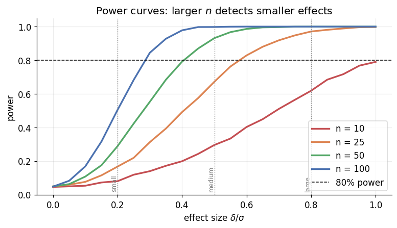

```python
# Figure: power curves vs effect size for each n, with Cohen marks and the 0.80 threshold.
rng = np.random.default_rng(123)
grid = np.linspace(0, 1.0, 21)
fig, ax = plt.subplots()
colors = {10: RED, 25: ORANGE, 50: GREEN, 100: BLUE}
for n in sizes:
    curve = []
    for d in grid:
        rej = 0
        for i in range(4000):
            s = rng.normal(d, 1.0, n)
            t = np.mean(s) / (np.std(s, ddof=1) / np.sqrt(n))
            rej += (2 * stats.t.sf(abs(t), df=n - 1) < 0.05)
        curve.append(rej / 4000)
    ax.plot(grid, curve, '-', color=colors[n], lw=2.2, label=f'n = {n}')
ax.axhline(0.80, color='k', ls='--', lw=1, label='80% power')
for b, name in [(0.2, 'small'), (0.5, 'medium'), (0.8, 'large')]:
    ax.axvline(b, color='gray', ls=':', lw=0.9)
    ax.text(b, 0.02, name, rotation=90, va='bottom', ha='right', fontsize=8, color='gray')
ax.set_xlabel(r'effect size $\delta/\sigma$'); ax.set_ylabel('power')
ax.set_title('Power curves: larger $n$ detects smaller effects'); ax.legend(loc='lower right')
plt.tight_layout(); plt.show()
```

### Multiple testing: paying for many looks

Run $m$ tests at level $\alpha$ and false alarms accumulate: with $m=20$ independent nulls, $\text{FWER}=1-(1-0.05)^{20}\approx0.64$. **Bonferroni** ($p_i<\alpha/m$) controls the family-wise error but bleeds power; **Benjamini-Hochberg** controls the *false discovery rate* and keeps more power. We run $200$ tests ($180$ true nulls, $20$ real effects of $\delta=0.5$).

```python
# Bonferroni vs Benjamini-Hochberg vs unadjusted across 200 simultaneous t-tests.
rng = np.random.default_rng(42)
n_tests, n_true_null, delta, n_per, alpha = 200, 180, 0.5, 30, 0.05
is_null = np.zeros(n_tests, dtype=bool); is_null[:n_true_null] = True

p_values = np.zeros(n_tests)
for i in range(n_tests):
    s = rng.normal(0.0 if is_null[i] else delta, 1.0, n_per)
    t = np.mean(s) / (np.std(s, ddof=1) / np.sqrt(n_per))
    p_values[i] = 2 * stats.t.sf(abs(t), df=n_per - 1)

raw = p_values < alpha
bonf = p_values < alpha / n_tests
order = np.argsort(p_values); sp = p_values[order]
thresh = np.arange(1, n_tests + 1) * alpha / n_tests
k_max = 0
for k in range(n_tests):
    if sp[k] <= thresh[k]:
        k_max = k + 1
bh = np.zeros(n_tests, dtype=bool); bh[order[:k_max]] = True

def report(name, rej):
    fp = int(np.sum(rej & is_null)); tp = int(np.sum(rej & ~is_null)); tot = int(np.sum(rej))
    fdr = fp / tot if tot else 0.0; pw = tp / np.sum(~is_null); fwer = int(fp > 0)
    print(f"{name:>12}  {tot:>8}  {fp:>4}  {tp:>4}  {fdr:>7.3f}  {pw:>7.3f}  {fwer:>5}")

print(f'200 tests: {n_true_null} true nulls, {n_tests-n_true_null} effects (delta={delta}, n={n_per})')
print(f"{'Method':>12}  {'Rejected':>8}  {'FP':>4}  {'TP':>4}  {'FDR':>7}  {'Power':>7}  {'FWER':>5}")
print('-' * 58)
report('Unadjusted', raw)
report('Bonferroni', bonf)
report('BH (FDR)', bh)
print()
print('Unadjusted: 70% power but 44% of "discoveries" are false. Bonferroni kills false')
print('positives but finds only 5/20. BH recovers 8/20 with no false discoveries here.')
```

```
200 tests: 180 true nulls, 20 effects (delta=0.5, n=30)
      Method  Rejected    FP    TP      FDR    Power   FWER
----------------------------------------------------------
  Unadjusted        25    11    14    0.440    0.700      1
  Bonferroni         5     0     5    0.000    0.250      0
    BH (FDR)         8     0     8    0.000    0.400      0

Unadjusted: 70% power but 44% of "discoveries" are false. Bonferroni kills false
positives but finds only 5/20. BH recovers 8/20 with no false discoveries here.
```

## E.5 — Optional / self-study: information, efficiency, and asymptotics

> **Optional / self-study.** This section goes beyond the four core simulations above. It verifies the deeper machinery the main chapters lean on — **Fisher information**, the **Cramér-Rao lower bound**, **MLE asymptotic normality**, and the **delta method** — each confirmed by Monte Carlo. Skim now; return to it alongside Chapter 3.

**Fisher information** $I_1(\theta)=\text{Var}(U(\theta))=-\mathbb E[\ell''(\theta)]$ is the curvature of the log-likelihood — how sharply the data pin down $\theta$. We verify the "variance of the score" form against the textbook values for four distributions.

```python
# Fisher information via the variance of the score, single-observation samples.
rng = np.random.default_rng(42)
N = 50000
print('Fisher information I_1(theta) = Var(score)   (50,000 single-obs samples)')
print(f"{'distribution':>20}  {'theory':>12}  {'sim Var(score)':>15}  {'ratio':>7}")
print('-' * 62)

lam = 3.0; x = rng.poisson(lam, N); sc = x/lam - 1
print(f"{'Poisson(3)':>20}  {1/lam:>12.6f}  {np.var(sc):>15.6f}  {np.var(sc)/(1/lam):>7.4f}")

mu, s2 = 5.0, 4.0; x = rng.normal(mu, np.sqrt(s2), N); sc = (x - mu)/s2
print(f"{'Normal(5, 4)':>20}  {1/s2:>12.6f}  {np.var(sc):>15.6f}  {np.var(sc)/(1/s2):>7.4f}")

le = 2.0; x = rng.exponential(1.0/le, N); sc = 1.0/le - x
print(f"{'Exp(2)':>20}  {1/le**2:>12.6f}  {np.var(sc):>15.6f}  {np.var(sc)/(1/le**2):>7.4f}")

p = 0.3; x = rng.binomial(1, p, N); sc = x/p - (1-x)/(1-p)
print(f"{'Bernoulli(0.3)':>20}  {1/(p*(1-p)):>12.6f}  {np.var(sc):>15.6f}  {np.var(sc)/(1/(p*(1-p))):>7.4f}")
print()
print('All ratios within ~1% of 1.0 -- the score-variance definition checks out.')
```

```
Fisher information I_1(theta) = Var(score)   (50,000 single-obs samples)
        distribution        theory   sim Var(score)    ratio
--------------------------------------------------------------
          Poisson(3)      0.333333         0.334244   1.0027
        Normal(5, 4)      0.250000         0.247060   0.9882
              Exp(2)      0.250000         0.249684   0.9987
      Bernoulli(0.3)      4.761905         4.756090   0.9988

All ratios within ~1% of 1.0 -- the score-variance definition checks out.
```

**Cramér-Rao lower bound.** No unbiased estimator beats $\text{Var}(\hat\theta)\ge 1/(nI_1(\theta))$. For the Poisson, $\bar X$ is the MLE and an exponential-family statistic, so it *achieves* the bound. We confirm $\text{Var}(\bar X)\approx 1/(nI_1)$ across $n$.

```python
# CRLB: Var(x-bar) vs 1/(n I_1) for Poisson(lambda=3).
rng = np.random.default_rng(42)
lam = 3.0; I1 = 1.0/lam; n_reps = 50000
ns_c, var_sim, crlb = [], [], []
print('CRLB check, Poisson(3):  I_1 = 1/lambda = %.6f' % I1)
print(f"{'n':>6}  {'Var(x-bar) sim':>14}  {'1/(n I_1)':>12}  {'ratio':>7}")
print('-' * 46)
for n in [10, 25, 50, 100, 500]:
    xb = np.array([np.mean(rng.poisson(lam, n)) for _ in range(n_reps)])
    v = np.var(xb); b = 1.0/(n*I1)
    ns_c.append(n); var_sim.append(v); crlb.append(b)
    print(f"{n:>6}  {v:>14.6f}  {b:>12.6f}  {v/b:>7.4f}")
print('Var(x-bar) tracks the bound to <1.5% -- the MLE is efficient for this exponential family.')
```

```
CRLB check, Poisson(3):  I_1 = 1/lambda = 0.333333
     n  Var(x-bar) sim     1/(n I_1)    ratio
----------------------------------------------
```

```
    10        0.296462      0.300000   0.9882
```

```
    25        0.118517      0.120000   0.9876
```

```
    50        0.059987      0.060000   0.9998
```

```
   100        0.029772      0.030000   0.9924
```

```
   500        0.006016      0.006000   1.0026
Var(x-bar) tracks the bound to <1.5% -- the MLE is efficient for this exponential family.
```

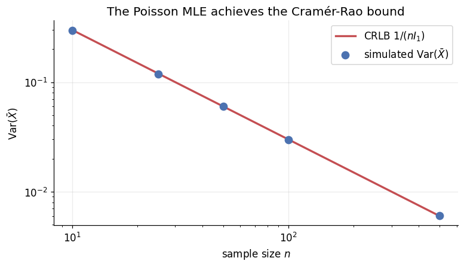

```python
# Figure: simulated Var(x-bar) sits on the Cramer-Rao bound 1/(n I_1) (log-log).
fig, ax = plt.subplots()
ax.plot(ns_c, crlb, '-', color=RED, lw=2.2, label=r'CRLB $1/(nI_1)$')
ax.plot(ns_c, var_sim, 'o', color=BLUE, ms=8, label=r'simulated $\mathrm{Var}(\bar X)$')
ax.set_xscale('log'); ax.set_yscale('log')
ax.set_xlabel('sample size $n$'); ax.set_ylabel(r'$\mathrm{Var}(\bar X)$')
ax.set_title('The Poisson MLE achieves the Cramér-Rao bound'); ax.legend()
plt.tight_layout(); plt.show()
```

**Asymptotic normality & the delta method.** Under regularity conditions $\sqrt n(\hat\theta-\theta_0)\xrightarrow{d}N(0,\,1/I_1(\theta_0))$, and a smooth transform inherits normality with variance scaled by $[g'(\theta)]^2$. Two checks on the Poisson MLE: its standardized error $\to N(0,1)$, and $g(\lambda)=\sqrt\lambda$ has the *variance-stabilizing* asymptotic variance $1/(4n)$ — free of $\lambda$.

```python
# (a) MLE asymptotic normality for Poisson(3); (b) delta method for g(lambda) = sqrt(lambda).
rng = np.random.default_rng(42)
lam = 3.0; I1 = 1.0/lam; n_reps = 50000

print('(a) Standardized MLE Z_n = sqrt(n I_1)(lambda_hat - lambda) -> N(0,1)')
print(f"{'n':>6}  {'Mean':>7}  {'Var':>7}  {'Skew':>7}  {'Kurt':>7}")
print('-' * 40)
for n in [10, 50, 200, 1000]:
    z = np.array([np.sqrt(n*I1)*(np.mean(rng.poisson(lam, n)) - lam) for _ in range(n_reps)])
    print(f"{n:>6}  {np.mean(z):>7.4f}  {np.var(z):>7.4f}  {stats.skew(z):>7.4f}  {stats.kurtosis(z):>7.4f}")

print()
print('(b) Delta method: Var(sqrt(lambda_hat)) ~ [g\'(lambda)]^2 Var(lambda_hat) = 1/(4n)')
for n in [25, 100, 500]:
    g = np.array([np.sqrt(np.mean(rng.poisson(lam, n))) for _ in range(n_reps)])
    sim = np.var(g); delta = 1.0/(4*n)
    print(f"  n={n:>4}: simulated = {sim:.6f}, delta = {delta:.6f}, ratio = {sim/delta:.4f}")
print('  The 1/(4n) variance is independent of lambda -- sqrt stabilizes the Poisson variance.')
```

```
(a) Standardized MLE Z_n = sqrt(n I_1)(lambda_hat - lambda) -> N(0,1)
     n     Mean      Var     Skew     Kurt
----------------------------------------
```

```
    10  -0.0005   0.9882   0.1750   0.0266
```

```
    50  -0.0015   0.9950   0.0720  -0.0004
```

```
   200  -0.0002   0.9986   0.0345  -0.0141
```

```
  1000  -0.0010   1.0038   0.0117   0.0175

(b) Delta method: Var(sqrt(lambda_hat)) ~ [g'(lambda)]^2 Var(lambda_hat) = 1/(4n)
```

```
  n=  25: simulated = 0.010015, delta = 0.010000, ratio = 1.0015
```

```
  n= 100: simulated = 0.002519, delta = 0.002500, ratio = 1.0076
```

```
  n= 500: simulated = 0.000494, delta = 0.000500, ratio = 0.9872
  The 1/(4n) variance is independent of lambda -- sqrt stabilizes the Poisson variance.
```

## Exercises

Each reinforces a pillar on a new angle. Try it before expanding the solution.

**Exercise 1 (E.3 coverage under skew).** The $t$-interval's 95% coverage assumes near-Normality. Simulate $10{,}000$ 95% $t$-intervals for the **skewed** $\text{Exp}(1)$ (mean $=1$) at $n\in\{5,15,50\}$ and show coverage is well below nominal at small $n$, recovering as the CLT engages. Contrast with $N(0,1)$ at $n=15$.

```python
# Solution 1.  One rng stream, seeded 42: Normal(0,1) first, then Exp(1) -- matches the webbook.
rng = np.random.default_rng(42)
n_reps = 10000; alpha = 0.05
print(f"{'parent':>12}  {'n':>4}  {'coverage':>9}")
print('-' * 29)
cap = 0
for i in range(n_reps):
    s = rng.normal(0.0, 1.0, 15); se = np.std(s, ddof=1)/np.sqrt(15)
    tc = stats.t.ppf(0.975, 14)
    cap += (np.mean(s) - tc*se <= 0.0 <= np.mean(s) + tc*se)
print(f"{'Normal(0,1)':>12}  {15:>4}  {cap/n_reps:>9.4f}")
for n in [5, 15, 50]:
    cap = 0
    for i in range(n_reps):
        s = rng.exponential(1.0, n); se = np.std(s, ddof=1)/np.sqrt(n)
        tc = stats.t.ppf(0.975, n - 1)
        cap += (np.mean(s) - tc*se <= 1.0 <= np.mean(s) + tc*se)
    print(f"{'Exp(1)':>12}  {n:>4}  {cap/n_reps:>9.4f}")
print('Normal: ~0.95 (exact). Exp(1): ~0.88 at n=5, climbing toward 0.95 as n grows.')
print('Skew breaks both CLT-normality of x-bar AND the x-bar / S independence the t-pivot needs.')
```

```
      parent     n   coverage
-----------------------------
```

```
 Normal(0,1)    15     0.9510
```

```
      Exp(1)     5     0.8822
```

```
      Exp(1)    15     0.9071
```

```
      Exp(1)    50     0.9386
Normal: ~0.95 (exact). Exp(1): ~0.88 at n=5, climbing toward 0.95 as n grows.
Skew breaks both CLT-normality of x-bar AND the x-bar / S independence the t-pivot needs.
```

**Exercise 2 (E.4 power, simulated vs analytical).** For the two-sided $t$-test ($n=25,\ \alpha=0.05$), sweep $\mu_1$ from 0 to 1 and compare **simulated** power to the **analytical** power from the noncentral-$t$ distribution (noncentrality $\delta\sqrt n$). They should agree within Monte-Carlo error.

```python
# Solution 2.
rng = np.random.default_rng(42)
n = 25; n_reps = 10000; alpha = 0.05
tcrit = stats.t.ppf(1 - alpha/2, df=n - 1)
print(f"{'mu1':>5}  {'simulated':>10}  {'analytical':>11}")
print('-' * 30)
for mu1 in np.arange(0, 1.05, 0.1):
    rej = 0
    for i in range(n_reps):
        s = rng.normal(mu1, 1.0, n)
        t = np.mean(s) / (np.std(s, ddof=1) / np.sqrt(n))
        rej += (2 * stats.t.sf(abs(t), df=n - 1) < alpha)
    ncp = mu1 * np.sqrt(n)
    anal = stats.nct.sf(tcrit, df=n - 1, nc=ncp) + stats.nct.cdf(-tcrit, df=n - 1, nc=ncp)
    print(f"{mu1:>5.1f}  {rej/n_reps:>10.4f}  {anal:>11.4f}")
print('Simulated and noncentral-t power agree to ~0.01; 80% power is reached near mu1 = 0.6.')
```

```
  mu1   simulated   analytical
------------------------------
```

```
  0.0      0.0518       0.0500
```

```
  0.1      0.0765       0.0768
```

```
  0.2      0.1522       0.1605
```

```
  0.3      0.3078       0.3020
```

```
  0.4      0.4883       0.4840
```

```
  0.5      0.6756       0.6697
```

```
  0.6      0.8237       0.8207
```

```
  0.7      0.9160       0.9188
```

```
  0.8      0.9688       0.9696
```

```
  0.9      0.9903       0.9907
```

```
  1.0      0.9981       0.9977
Simulated and noncentral-t power agree to ~0.01; 80% power is reached near mu1 = 0.6.
```

**Exercise 3 (E.4 p-value calibration).** Confirm the *Uniform-under-$H_0$* theorem by binning $10{,}000$ $H_0$ p-values into deciles (each $\approx0.10$), then report the mean p-value and rejection rate at $\alpha=0.05$ under $H_1$ for $\delta\in\{0.2,0.5,0.8\}$.

```python
# Solution 3.
rng = np.random.default_rng(42)
n = 25; n_reps = 10000
p0 = np.zeros(n_reps)
for i in range(n_reps):
    s = rng.normal(0.0, 1.0, n)
    t = np.mean(s) / (np.std(s, ddof=1) / np.sqrt(n))
    p0[i] = 2 * stats.t.sf(abs(t), df=n - 1)
print('P-value deciles under H0 (each should be ~0.10):')
for k in range(10):
    lo, hi = k/10, (k+1)/10
    print(f'  [{lo:.1f}, {hi:.1f})  {np.mean((p0>=lo)&(p0<hi)):.4f}')
print()
print('Under H1:   delta   mean p   P(p<0.05)')
for d in [0.2, 0.5, 0.8]:
    p1 = np.zeros(n_reps)
    for i in range(n_reps):
        s = rng.normal(d, 1.0, n)
        t = np.mean(s) / (np.std(s, ddof=1) / np.sqrt(n))
        p1[i] = 2 * stats.t.sf(abs(t), df=n - 1)
    print(f'           {d:>5.1f}   {np.mean(p1):>6.4f}   {np.mean(p1<0.05):>8.4f}')
print('Deciles ~0.10 confirm uniformity; mean p falls and power rises as the effect grows.')
```

```
P-value deciles under H0 (each should be ~0.10):
  [0.0, 0.1)  0.1021
  [0.1, 0.2)  0.0950
  [0.2, 0.3)  0.1021
  [0.3, 0.4)  0.1010
  [0.4, 0.5)  0.1002
  [0.5, 0.6)  0.0983
  [0.6, 0.7)  0.1025
  [0.7, 0.8)  0.1015
  [0.8, 0.9)  0.0992
  [0.9, 1.0)  0.0981

Under H1:   delta   mean p   P(p<0.05)
```

```
             0.2   0.3714     0.1622
```

```
             0.5   0.0810     0.6702
```

```
             0.8   0.0068     0.9713
Deciles ~0.10 confirm uniformity; mean p falls and power rises as the effect grows.
```

## Summary & connections forward

Every inferential guarantee in this appendix was **simulated, not asserted** — and the theory held to Monte-Carlo precision.

| Concept | Key result | Confirmed by |
| --- | --- | --- |
| Bias-variance | $\text{MSE}=\text{Bias}^2+\text{Var}$ | biased $\hat\sigma^2$ wins MSE at every $n$ |
| Sampling dist. | $\bar X\sim N(\mu,\sigma^2/n)$, $(n-1)S^2/\sigma^2\sim\chi^2_{n-1}$, $\bar X\perp S^2$ | matched means/vars, $\text{corr}\approx0$ |
| $t$ pivot | heavier tails, $\text{Var}=\tfrac{n-1}{n-3}$ | $1.16$ at $n=15$ |
| CLT | $\sqrt n(\bar X-\mu)/\sigma\to N(0,1)$ | skewness $\sim1/\sqrt n$ for 3 parents |
| Coverage | $P(\theta\in\text{CI})=1-\alpha$ | $93.5\%$ over 200 $t$-intervals |
| Wald failure | collapses at small $np$ | $40.3\%$ coverage at $n=10$ |
| p-value | Uniform$(0,1)$ under $H_0$ | flat deciles, reject rate $=\alpha$ |
| Power | $1-\beta$ grows in $\delta,\,n$ | grid + noncentral-$t$ agree |
| Fisher info / CRLB | $\text{Var}(\hat\theta)\ge 1/(nI_1)$ | Poisson $\bar X$ on the bound |

**Forward.** **Chapter 3** turns the likelihood, score, and Fisher information into MLEs, Wald intervals, and GLMs. **Chapter 4** replaces the asymptotic standard errors and CIs verified here with the **bootstrap** — a resampling route to the same sampling distribution when the formulas are shaky (small $n$, boundaries, messy statistics). **Chapter 5** reinterprets the interval itself: a Bayesian **credible** interval carries a posterior probability of containing $\theta$, in contrast to the repeated-sampling **coverage** guarantee dissected in E.3.